# TSS correlation (FANTOM3 and 4)

Martin Iungman

2022-08-19

El objetivo de este código es analizar la correlacion en expresión entre TSS cluster de un gen. / Particularmente usando de FANTOM3 y FANTOM4. / Como primer approach, para simplificar, uso solo los genes que tienen dos “true TSS”.

```r
library(FANTOM3and4CAGE)
library(rtracklayer)
library(tidyverse)
library(glue)
```

Los tejidos humanos presentes en el dataset (todos con una unica replica):

```r
data(FANTOMtissueCAGEhuman)
names(FANTOMtissueCAGEhuman)
```

```
##  [1] "cerebrum"        "renal_artery"    "ureter"          "urinary_bladder"
##  [5] "kidney"          "small_intestine" "rectum"          "cecum"
##  [9] "liver"           "large_intestine" "prostate_gland"  "mammary_gland"
## [13] "epididymis"      "skin"            "adipose"         "pancreas"
## [17] "thymus"          "undefined"       "blood"           "lung"
## [21] "adrenal_gland"   "colon"           "brain"           "cerebellum"
## [25] "testis"          "embryo"          "bone_marrow"     "heart"
## [29] "muscle"          "frontal_lobe"    "occipital_lobe"  "parietal_lobe"
## [33] "spleen"          "breast"
```

Usamos los datos “normales” (no timecourse ni enfermedades)

```r
data<-map2(FANTOMtissueCAGEhuman, names(FANTOMtissueCAGEhuman), ~.x%>%select(matches(str_glue("chr|pos|strand|{.y}|control"))))
for(i in 1:length(data)){
  if(any(names(data[[i]])=="control")){
    var=names(data)[i]
    data[[i]]<-data[[i]]%>%rename({{var}}:=control)
  }
}
data<-keep(data,~ncol(.x)==4)
```

Veo profuncidad de secuenciaciòn en las muestras (suma de counts totales)

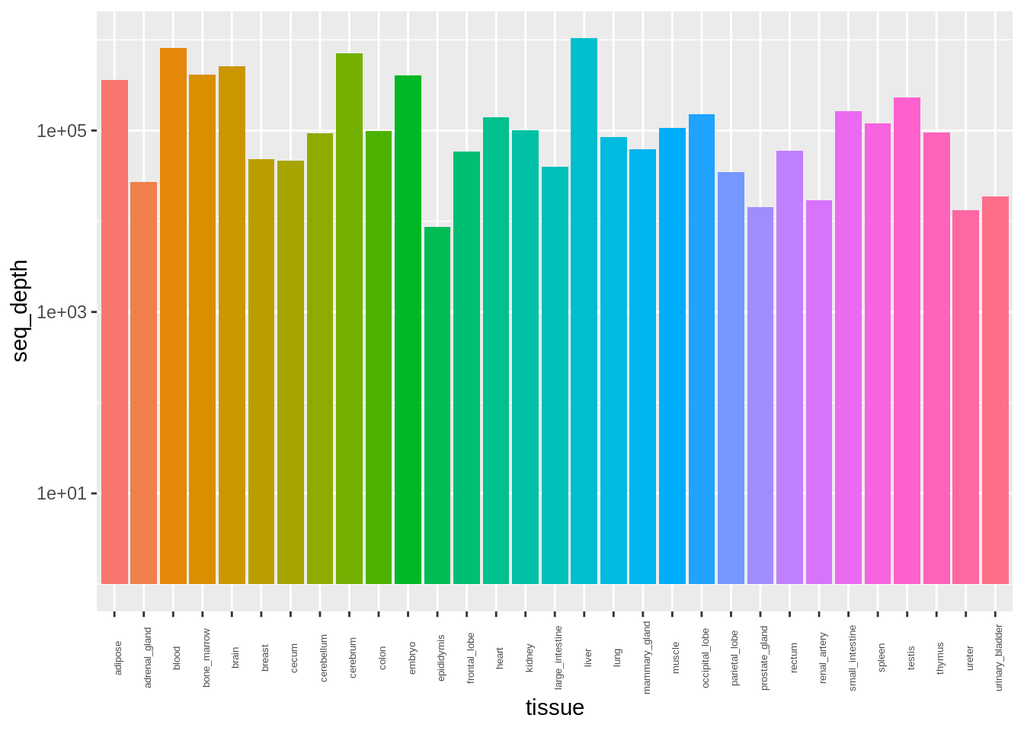

```r
seq_depth<-map_dfr(data,~sum(.x[[4]]))%>%t()%>%as.data.frame()%>%rownames_to_column(var="tissue")%>%rename(seq_depth=V1)
ggplot(seq_depth, aes(y=seq_depth, x=tissue,fill=tissue))+geom_bar(stat="identity")+scale_y_log10()+theme(axis.text.x = element_text(size=5,angle=90),legend.position = "none")
```

Luego, hago overlap de las muestras con los true TSS. Pero como la data de True TSS esta en hg19 y las muestras en hg18, tengo que hacer Lift Over (descargando la data de UCSC).

```r
h37_tss_selected_gr<-import.bed("Tables/h37_tss_selected_gr.bed")
h18_tss_selected<-unlist(liftOver(h37_tss_selected_gr, chain=import.chain("Data/hg19ToHg18.over.chain")))
find.tss.selected<-function(data,true.tss,colname){
  a<-findOverlaps(true.tss, data, ignore.strand = F)
  data.frame(name= true.tss$name[queryHits(a)],
             Raw_count = mcols(data)$score[subjectHits(a)])%>%
    group_by(name) %>% summarise(across(Raw_count,sum,.names="sum_{colname}"))
}
data_gr<-map(data,~GRanges(seqnames=.x[[1]],range=IRanges(start = .x[[2]],width=1),strand=.x[[3]],score=.x[[4]]))
tss_sel<-map2(data_gr,names(data_gr),~find.tss.selected(.x,h18_tss_selected,.y))
```

Calculo counts totales sumando la señal de todas las muestras y filtro en un minimo de 10.  
Calculo cantidad de muestras donde la señal es mayor a 1 y establezco un minimo de 3 muestras.

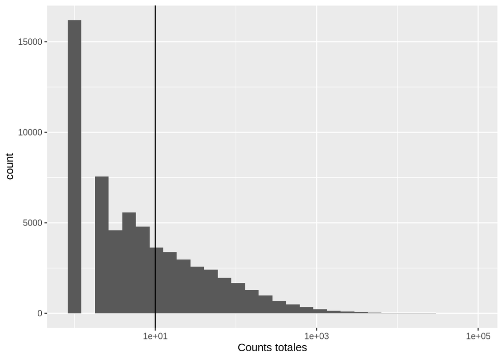

```r
prom_df<-read_csv("Tables/clusters_selected_genes.csv")%>%select(cluster_id,gene_symbol)
tss_sel_df<-purrr::reduce(tss_sel, full_join, by="name")%>%
  mutate(across(.cols=where(is.numeric),.fns = ~replace_na(.x,replace=0)))
tss_sel_df<-left_join(tss_sel_df,prom_df, by=c("name"="cluster_id"))
tss_sel_df<-tss_sel_df%>%rowwise()%>%mutate(counts_tot=sum(c_across(starts_with("sum"))), n_samples=sum(c_across(starts_with("sum"))>1))%>%ungroup()
tss_sel_df%>%ggplot(aes(counts_tot))+geom_histogram()+scale_x_log10()+xlab("Counts totales")+geom_vline(xintercept = 10)
```

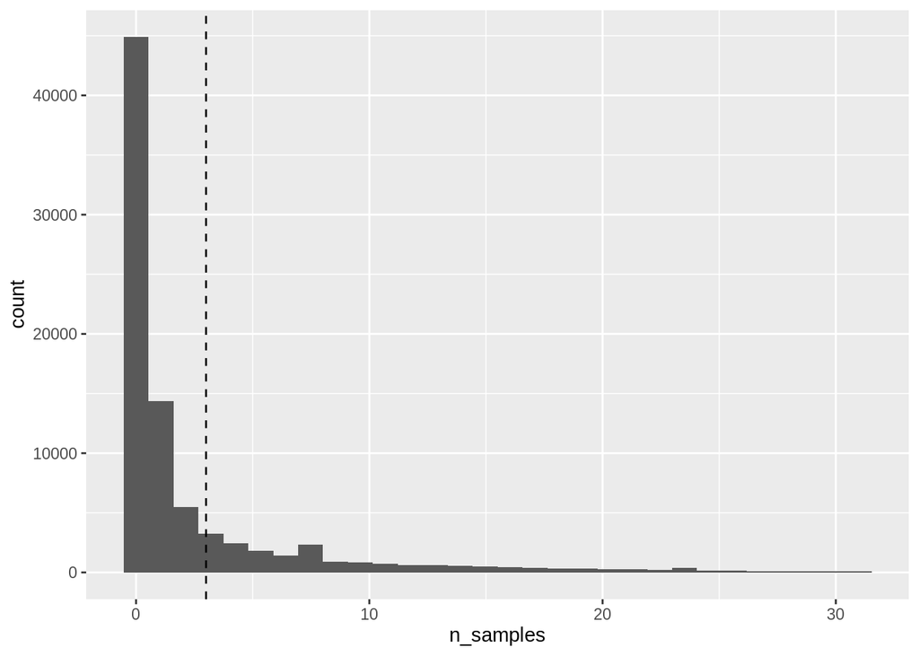

```r
tss_sel_df%>%ggplot(aes(n_samples))+geom_histogram()+geom_vline(xintercept = 3,linetype="dashed")
```

```r
tss_sel_df<-tss_sel_df%>%filter(counts_tot>=10, n_samples>=3)
```

Veamos la relación entre estas dos variables:

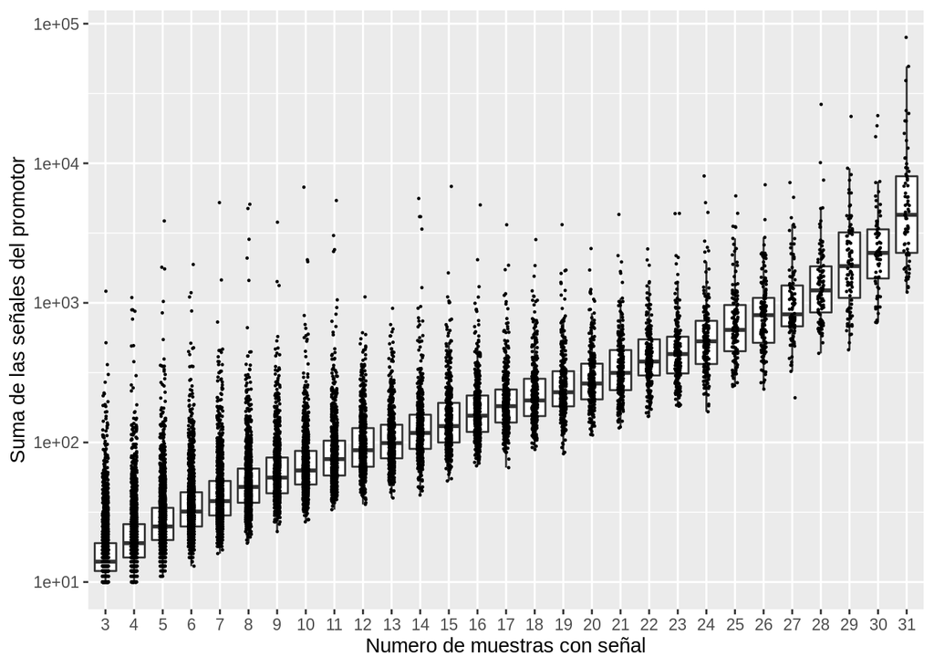

```r
tss_sel_df%>%ggplot(aes(x=as_factor(n_samples),y=counts_tot))+geom_boxplot(outlier.alpha = 0)+geom_jitter(width=0.1,size=0.2)+scale_y_log10()+xlab("Numero de muestras con señal")+ylab("Suma de las señales del promotor")
```

La tendencia es clara: en terminos globales, los promotores que se expresan mas, presentan señal en mas muestras. Sera azar?.  
Hay casos que se escapan a esta tendencia (observados en pocos tejidos y con alto numero de counts).

Ahora armo las correlaciones para los genes con dos promotores que hayan cumplido las condiciones

```r
prom_list<-tss_sel_df%>%select(-n_samples,-counts_tot)%>%group_split(gene_symbol)%>%map(unique)%>%keep(~nrow(.x)==2)%>%map(~.x%>%pivot_longer(starts_with("sum"),names_to="tissue",values_to = "counts"))
prom_list<-map(prom_list, ~.x%>%pivot_wider(names_from = name,values_from = counts))
#calculo correlacion de spearman para cada uno
cor_vector<-map_dbl(prom_list,~cor(.x[[grep("^p", names(.x))[1]]],
    .x[[grep("^p", names(.x))[2]]],method = "spearman"))
names(cor_vector)<-map_chr(prom_list,~unique(.x$gene_symbol))
```

```
## Se analizaron 2584 genes.  116 tienen correlacion mayor a 0.8. 280 tienen correlacion menor a 0.25
```

En el siguiente grafico veo la densidad de las correlaciones. Llama la atención que no haya ningún caso con una fuerte correlación negativa (que indicaría cambio de promotor alternativo en todas las muestras)

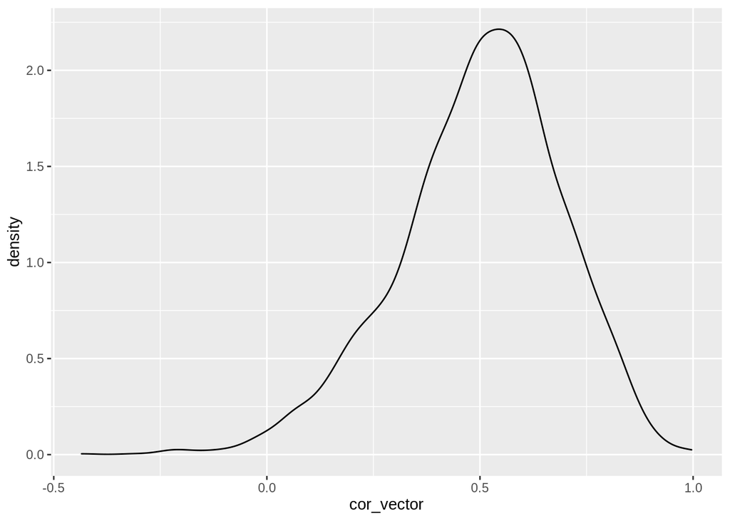

```r
as.data.frame(cor_vector)%>%ggplot(aes(cor_vector))+geom_density()
```

Un punto para pensar podría ser la ausencia de mecanismos tipo “switch” (al menos consistente entre todas las muestras), dado que no hay practicamente casos de fuerte correlacion negativa.

### Relacion entre la correlacion y la distancia entre ambos promotores

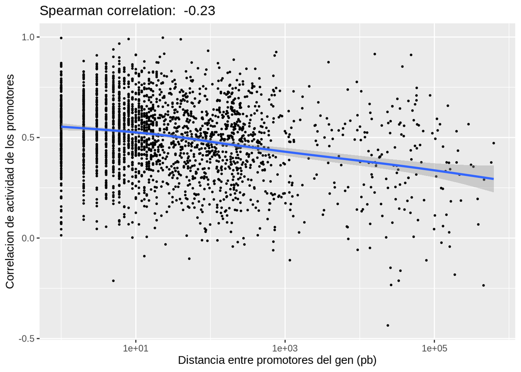

```r
cor_df<-as.data.frame(cor_vector)%>%rownames_to_column(var="gene_symbol")%>%left_join(tss_sel_df, by="gene_symbol")
h18_filt<-subset(h18_tss_selected, name%in%unlist(prom_list%>%map(~names(.x)[-c(1,2)])))
mcols(h18_filt)<-mcols(h18_filt)%>%as_tibble()%>%mutate(gene=str_remove_all(name,"(p.@)|(,.+)"))
gr_list_genes<-split(h18_filt, h18_filt$gene)
dist_to_near_intra<-map(as.list(gr_list_genes),distanceToNearest)
dist_df<-data.frame(
  cluster_id=unlist(map2(as.list(gr_list_genes),dist_to_near_intra,~.x[queryHits(.y)]$name)),
  nearest_id=unlist(map2(as.list(gr_list_genes),dist_to_near_intra,~.x[subjectHits(.y)]$name)),
  distances=unlist(map(dist_to_near_intra, ~as_vector(mcols(.x)))))
cor_dist<-cor_df%>%left_join(dist_df, by=c("name"="cluster_id"))%>%select(distances,cor_vector, gene_symbol)%>%unique()
cor_dist%>%ggplot(aes(distances, cor_vector))+geom_point(size=0.5)+geom_smooth()+scale_x_log10()+xlab("Distancia entre promotores del gen (pb)")+ylab("Correlacion de actividad de los promotores")+
  ggtitle(str_glue("Spearman correlation:  ", {cor(cor_dist$distances,cor_dist$cor_vector,use="pairwise.complete.obs",method="spearman")%>%round(digits=2)}))
```

Resultado esperado… Mas cercanos los TSS clusters, mas correlacionada su actividad, Bastante bajo el r igualmente……..

## Bonus track: explorando un poco mas la distribucion de promotores

### De que depende el numero de promotores observados???

Una posibilidad seria que la cantidad de promotores por gen en la base de datos responda a la cantidad total de señal asociada al gen a lo largo de todas las muestras.  
Pero vemos que no en el siguiente grafico:

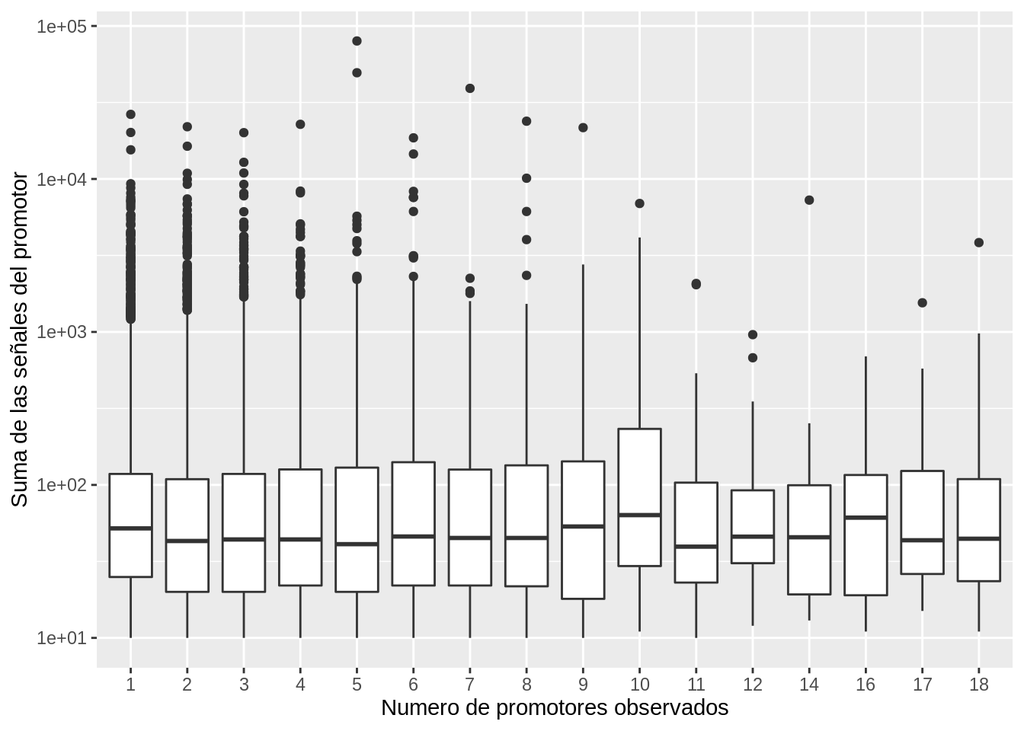

```r
tss_sel_df%>%group_by(gene_symbol)%>%summarise(n_prom=n(),counts_tot)%>%
  ggplot(aes(as_factor(n_prom),counts_tot))+geom_boxplot()+scale_y_log10()+xlab("Numero de promotores observados")+ylab("Suma de las señales del promotor")
```

Otra posibilidad seria que que la cantidad de clusterTSS con señal en una muestra este asociado a la expresion del gen en esa muestra. Hago una correlacion de Spearman para cada gen entre expresion del gen (suma de todos sus clusterTSS) y el numero de clusterTSS “activos” (señal>1), para cada tejido analizado. Un valor por tejido.

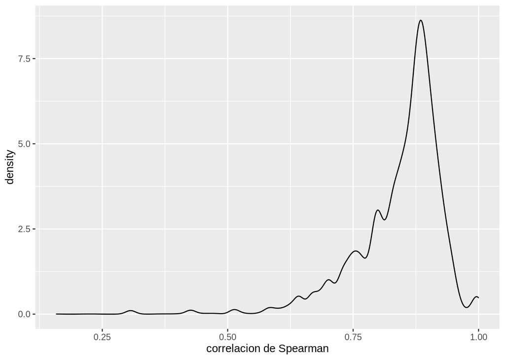

```r
prom_list2<-tss_sel_df%>%select(-n_samples,-counts_tot)%>%group_split(gene_symbol)%>%map(unique)%>%
  map(~.x%>%pivot_longer(starts_with("sum"),names_to="tissue",values_to = "counts"))
prom_list2<-map(prom_list2, ~.x%>%pivot_wider(names_from = name,values_from = counts))
prom_list2<-map(prom_list2,~.x%>%rowwise()%>%mutate(sum=sum(c_across(starts_with("p"))), n_prom_act=sum(c_across(starts_with("p"))>1)))

cor_vector2<-map_dbl(prom_list2,~cor(.x$sum,
                                   .x$n_prom_act,method = "spearman"))
names(cor_vector2)<-map_chr(prom_list2,~unique(.x$gene_symbol))
as.data.frame(cor_vector2)%>%ggplot(aes(cor_vector2))+geom_density()+xlab("correlacion de Spearman")
```

```r
prom_list3<-keep(prom_list2,~ncol(.x)>=6)
cor_vector3<-cor_vector2[which(names(cor_vector2)%in%map_chr(prom_list3,~unique(.x$gene_symbol)))]
```

Fuerte correlación en la gran mayoría de los genes…. Muestro un ejemplo:

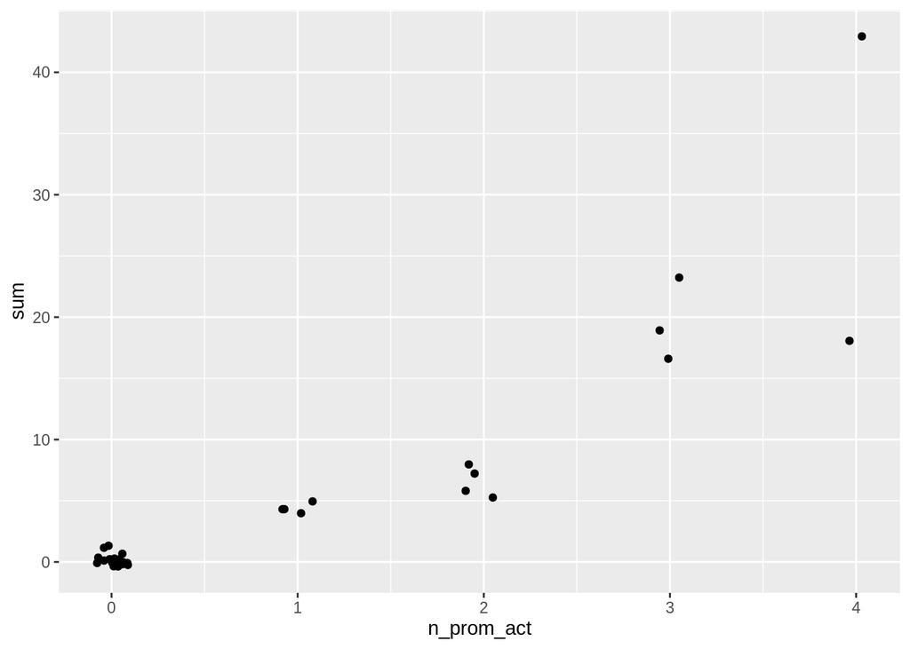

```r
ggplot(prom_list3[[9]],aes(n_prom_act,sum))+geom_jitter(width=0.1)
```

Pero cual es causa y cual consecuencia?  
La respuesta “obvia” sería que si tenes mas clusterTSS activos, vas a tener mayor señal total…  
PERO. Tambien podria ser que, para clusterTSS relativamente cercanos principalmente, la mayor actividad promotora de uno, abra la cromatina, reclute factores y genere señal en otros clusterTSS. En este sentido, vuelvo a la hipotesis de que clusterTSS mas debiles serian consecuencia de un clusterTSS principal. Tambien lo podriamos pensar, obviamente, como un TSS broad muy amplio.

### Ideas disparadoras:

- Genes con promotor caracterizado como broad, presentan multiples clusterTSS cercanos?
- Recordar paper sobre NSL…
- Promotores bidireccionales… Como se compartan los promotores alternativos de esos genes?
- Usar ATAC-seq u otra tecnica para ver como se asocia la amplitud de la apertura cromatinica con la activacion de multiples clusterTSS
- Independizarme de la clasificacion de FANTOM de TrueTSS y ver el continuo de señales. Tal vez usando los inicios de UCSC como orientadores.

Igualmente, todo esto es exploratorio. Tengo que repetir todos estos analisis agregando la base de datos de FANTOM5.